# Indirect Genetic Effects: Height Analysis Dataframes

Melisa Chuong

25/01/2021

# Explore Indirect Genetic Effects using Regressions and Pathway Analyses

# Aim

I will be using trio’s full polygenic risk scores rather than splitting PRSs into transmitted and non-transmitted counterparts.

# GS TRIOS

Genotyped data and pedigree files can be found on datastore @ /exports/igmm/eddie/GenScotDepression/data/genscot/genetics/genotypes/GS20K_PLINK_files/QCd_data  
*These files are saved as GS_QC.bed/.bim/.fam*

I find genotyped GS trios using the pedigree file available, from this we create a GS_trio file.

```r
rm(list=ls())

fam <- read.table("GS_QC.fam") #this file was renamed for convenience
colnames(fam) <- c("FID", "IID", "PID", "MID", "SEX", "PHENO")

fatherpresent <- fam[fam$PID%in%fam$IID,] #Finding PIDs also present in the IID column - every individual in the IID column in the pedigree file has genotyped data#
dim(fatherpresent) #fatherduo n= 3,865

motherpresent <- fam[fam$MID%in%fam$IID,] #Finding MIDs also present in the IID column#
dim(motherpresent) #motherduo n=5,954

trio <- fam[fam$PID%in%fam$IID & fam$MID%in%fam$IID,] #Finding trios, i.e. individuals with both PIDs and MIDs present in the IID column#

write.table(trio, "GS_trio", row.names=F, quote=F)
#n= 2680 genotyped trios available in Generation Scotland
```

# PHENOTYPES

Our phenotype of interest is height, measured in CMs. We can find this variable within the masterDB.Rdata file, which can be found on datastore @ /exports/igmm/GenScotDepression/data/genscot/phenotypes/masterDB.Rdata

## Height

```r
rm(list=ls())

df <- load("masterDB.Rdata")
which(colnames(totaldata)=="height")

#column IID =1, FID =79, HEIGHT=34
height <- totaldata[,c(1,34,79)]

#Reordering so column order is FID, IID, HEIGHT
height <- height[,c(3,1,2)] #n=24,075
height <- height[complete.cases(height),] #n=21,450

colnames(height) <- c("FID", "IID", "HEIGHT")
hist(height$HEIGHT, col="green4")
summary(height$HEIGHT) #I am 10 cms shorter than the average scot :(


write.table(height, "GSheight", row.names=F, quote=F)
```

## QC Phenotype

Removing phenotype values that are greater or less than 4 standard deviations away from the mean (i.e. outliers!) - after controlling for AGE and SEX!  
Age and sex variable files provided by Carmen Amador.  
8 Outliers are removed from the whole GS sample.

```r
age <- read.table("GS_Ages.qcovar", header=T)
age <- age[,1:3]
colnames(age) <- c("FID", "IID", "AGE")

sex <- read.table("GS_SexClinic.fcovar", header=T)
sex <- sex[,1:3]
colnames(sex) <- c("FID", "IID", "SEX")

cov <- merge(age, sex, by=c("FID", "IID"))

colnames(height) <- c("FID", "IID", "HEIGHT")

df1 <- merge(height, cov, by=c("FID", "IID")) #n=20,026

#We need to remove individuals with NA data
df1 <- df1[!is.na(df1$HEIGHT),] #n=19,961

#Regressing out the effects of AGE and SEX
reg <- lm(HEIGHT~AGE+SEX, data=df1)
res <- data.frame(FID=df1$FID, IID=df1$IID, HEI_res=residuals(reg))

summary(res$HEI_res)
sd(res$HEI_res)

outlierIDs_positive <- subset(res, res$HEI_res>mean(res$HEI_res)+4*sd(res$HEI_res))
outlierIDs_negative <- subset(res, res$HEI_res<mean(res$HEI_res)-4*sd(res$HEI_res))

outlierIDs <- rbind(outlierIDs_positive, outlierIDs_negative)#n=8

#We only actually need the identity numbers of the outliers
outlierIDs <- outlierIDs[,1:2]

write.table(outlierIDs, "heightOUTLIERS", row.names=F, quote=F)

#Now removing outliers from our height variable
cleanheight <- height[!(height$IID%in%outlierIDs$IID),] #n=(21,450-8) 21,442

trio <- read.table("GS_trio", header=T)
df2 <- merge(trio, cleanheight, by=c("FID", "IID"), all.x=T)
colnames(cleanheight)[2:3] <- c("MID", "mHEIGHT")
df3 <- merge(df2, cleanheight, by=c("FID", "MID"), all.x=T)
colnames(cleanheight)[2:3] <- c("PID", "pHEIGHT")
df4 <- merge(df3, cleanheight, by=c("FID", "PID"), all.x=T)
```

## Phenotype Demographics

hist + var + sd (offspring)

```r
#offspring height demographics

df4 <- df4[complete.cases(df4),] #Using trios with COMPLETE data; n=2,648
hist(df4$HEIGHT, col="cadetblue3")

summary(df4$HEIGHT)
var(df4$HEIGHT)
sd(df4$HEIGHT)
```

```r
#maternal height demographics

hist(df4$mHEIGHT, col="lightpink1")

summary(df4$mHEIGHT)
var(df4$mHEIGHT)
sd(df4$mHEIGHT)
```

hist + var + sd (paternal)

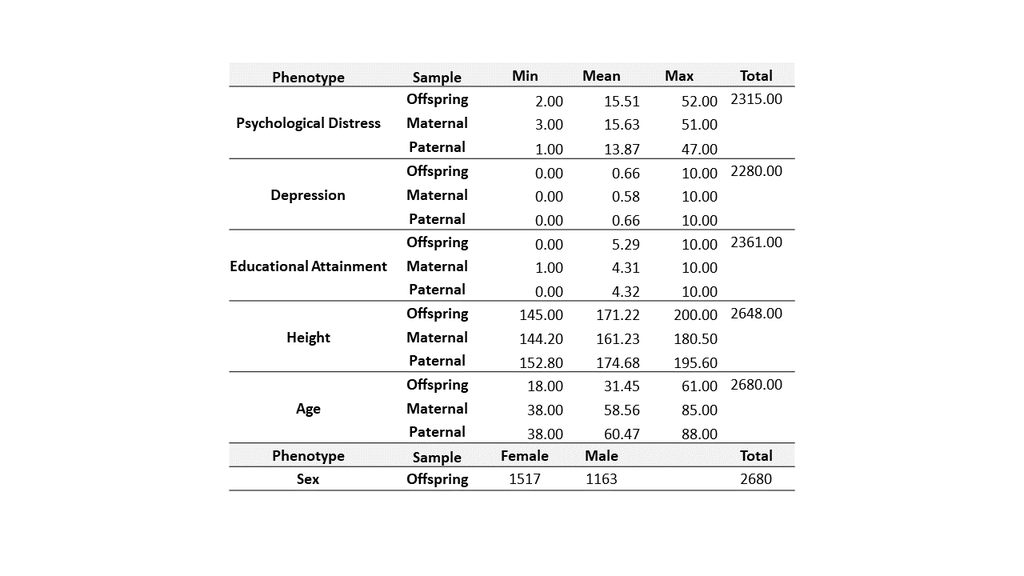

```r
#paternal height demographics

hist(df4$pHEIGHT, col="darkolivegreen3")

summary(df4$pHEIGHT)
var(df4$pHEIGHT)
sd(df4$pHEIGHT)
```

# POLYGENIC RISK SCORES

We will use PRSice2 (Choi & O’Reilly., 2019) to generate the PGSs. We will pre-correct our phenotypes for covariates. We will use 1000G as a reference panel for LD estimation which will go onto guide pruning and clumping of SNPs.

Covariates include the first 20 principle components from a Genomics Relatedness Matrix of GS data, age and sex.

PCs can be found on datastore @ /exports/igmm/datastore/GenScotDepression/data/genscot/genetics/genotypes/GS20K_PLINK_files/PCA_MDS_components/HM3mds.mds

Age and sex covariate data is provided by Carmen Amador @ /gpfs/igmmfs01/eddie/haley-lab/melisa/dataformelisa/GS_SexClinic.fcovar / GS_Ages.qcovar

We are creating height PRSs for EVERYONE with height data in GS, not just trios - this allows the effects of covariates to be controlled for with a little more accuracy.

## Covariate Correction

```r
library(dplyr)

age <- read.table("GS_Ages.qcovar", header=T)
age <- age[,c(1:3)] #2 columns with age measured in different formats, using the years (column)
colnames(age) <- c("FID", "IID", "AGE")#n=20,032

sex <- read.table("GS_SexClinic.fcovar", header=T)
sex <- sex[,c(1:3)] #just using the sex info
colnames(sex) <- c("FID", "IID", "SEX")
sex$SEX <- as.factor(sex$SEX)#n=20,032

pcs <- read.table("HM3mds.mds", header=T)
pcs <- distinct(pcs, IID, .keep_all = TRUE) #Some IIDs are repeated, so need to sort this out#
head(pcs)
pcs <- pcs[,-3]#n=20,142

cov <- merge(age, sex, by=c("FID","IID"))
cov <- merge(cov, pcs, by=c("FID", "IID"))#n=19,990

df1 <- merge(height, cov, by=c("FID","IID"))
df1 <- df1[complete.cases(df1),] #n=19,923

reg <- lm(HEIGHT~C1+C2+C3+C4+C5+C6+C7+C8+C9+C10+C11+C12+C13+C14+C15+C16+C17+C18+C19+C20+AGE+SEX, data=df1)
summary(reg)
result <- data.frame(FID=df1$FID, IID=df1$IID, HEI_res=residuals(reg))

write.table(result, "GSheight_res", row.names=F, quote=F)
#it is ok if the phenotype used in PRSice analyses is not standardised - we are interested in the amount of accounted variance R2 attributable to the PRSs
```

1000G files need to be in the format of plink1 files. Plink2 versions are available on datastore @ /exports/igmm/datastore/GenScotDepression/data/resources/1000g/PGEN

Need to convert vzs plink2 versions of files to .bed.bim.fam plink1 versions plink2.00 is used for this

```
plink --pfile all_phase3 --max-allele 2 --make-bed --out all_phase3
```

## Computing PGSs

We will use:

Base data: Height GWAS meta-analysis sumstats ~ Yengo et al., 2018: Wood et al., 2014 N= 253,288 individuals (NO GENSCOT) + UKB (Sample size of 693,529)

LD data: 1000G LD structure (see above)

Phenotype data: The GSheight_res file we created above. This is height for all GS participants with the effects of age, sex and 20PCs removed

Target data: Will be the available plink files for GS; GS_QC.bed, GS_QC.bim, GS_QC.fam

We will be creating different PRSs whereby the number of SNPs used to inform the PRSs will be dependent on the SNPs p-value GWAS association with the trait. We use 10 different p-value association thresholds ranging from 5x10-8 : 1.

Shell script

```
#!/bin/sh
###########################################

# M.Chuong, Edinburgh U.K, January2020
# Eddie HEIGHT PRSice Script

#$ -N GenScotHeightPRS
#$ -cwd
#$ -pe sharedmem 2 # number of cores
#$ -l h_vmem=40G # memory per core
#$ -l h_rt=12:00:00 ## requested time
#$ -m baes ## notifications: (b)begin/(a)aborted/(e)end/(s)suspended/(n)nomail
#$ -M melisa.chuong@ed.ac.uk ## email for notifications

# INITIALISE ENV MODULES
. /etc/profile.d/modules.sh # if using modules need to add this line
# LOAD THE MODULES
module load igmm/apps/R/3.3.3


Rscript PRSice.R\
--dir .\
--prsice ./PRSice_linux\
--base Meta-analysis_Wood_et_al+UKBiobank_2018.txt\
--target GS_QC\
--thread 1\
--print-snp\
--beta\
--stat Effect\
--binary-target F\
--snp MarkerName\
--A1 Allele1\
--A2 Allele2\
--se StdErr\
--pvalue P-value\
--bar-levels 0.00000005,0.0000005,0.000005,0.00005,0.0005,0.005,0.05,0.5,0.75,1\
--fastscore\
--all-score\
--ld all_phase3\
--pheno-file GSheight_res\
--pheno-col HEI_res\
--out GSheight
```

Summary of generated PRSs  
Currently, PGSs informed by SNPs exceeding the genome-wide p-value threshold of 0.05 accounts for the greatest amount of variance in comparison to the other PGSs.  
histogram of PRSs standardised

```r
rm(list=ls())

hprs <- read.table("GSheight.all.score", header=T)
head(hprs)
hprs <- hprs[,c(1:2,9)]
colnames(hprs)[3] <- c("heiPRS_0.05")

hprs$heiPRS_0.05 <- scale(hprs$heiPRS_0.05)
hist(hprs$heiPRS_0.05, col="orange")#distribution seems normal
```

height PRS - height summary

```r
hprs$heiPRS_0.05 <- scale(hprs$heiPRS_0.05)
summary(hprs$heiPRS_0.05)

hei_prs <- read.table("GSheight.prsice")
hei_prs
```

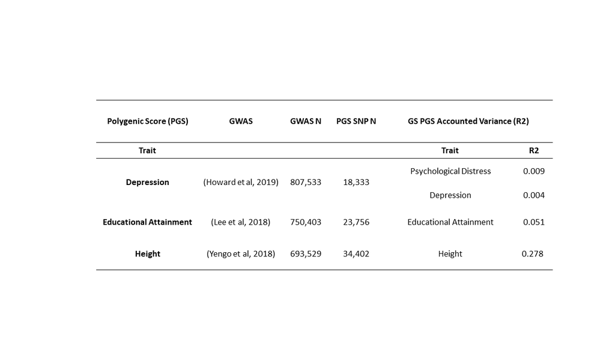

# SANITY CHECKS

## Sanity Check Dataframe

Resulting DF has ALL variables standardised!

```r
dim(hprs)

df <- read.table("GS_trio", header=T)
df <- df[,c(1:4)]

GSheight <- read.table("GSheight", header=T)
outliers <- read.table("heightOUTLIERS", header=T)
GSheight <- GSheight[!(GSheight$IID%in%outliers$IID),]
GSheight$HEIGHT <- scale(GSheight$HEIGHT)

df1 <- merge(df, GSheight, by=c("FID", "IID"), all.x=T)

colnames(GSheight)[2:3] <- c("MID", "mHEIGHT")
df2 <- merge(df1, GSheight, by=c("FID", "MID"), all.x=T)

colnames(GSheight)[2:3] <- c("PID", "pHEIGHT")
df3 <- merge(df2, GSheight, by=c("FID", "PID"), all.x=T)

df4 <- merge(df3, hprs, by=c("FID", "IID"))

colnames(hprs)[2:3] <- c("MID","mheiPRS_0.05")
df5 <- merge(df4, hprs, by=c("FID", "MID"))

colnames(hprs)[2:3] <- c("PID","pheiPRS_0.05")
df6 <- merge(df5, hprs, by=c("FID", "PID"))

age <- read.table("GS_Ages.qcovar", header=T)
age <- age[,c(1:3)]
age$age <- scale(age$age)
colnames(age) <- c("FID", "MID", "mAGE")

df7 <- merge(df6, age, by=c("FID", "MID"))
colnames(age) <- c("FID", "PID", "pAGE")
df8 <- merge(df7, age, by=c("FID", "PID"))

library(dplyr)

colnames(age)[2:3] <- c("IID", "AGE")
sex <- read.table("GS_SexClinic.fcovar", header=T)
head(sex)
sex <- sex[,c(1:3)]
colnames(sex) <- c("FID", "IID", "SEX")
sex$SEX <- as.factor(sex$SEX)
dim(sex)

pcs <- read.table("HM3mds.mds", header=T)
pcs <- distinct(pcs, IID, .keep_all = TRUE) #Some IIDs are repeated, so need to sort this out#
head(pcs)
pcs <- pcs[,-3]
pcs[,3:22] <- scale(pcs[,3:22])

cov <- merge(age, sex, by=c("FID","IID"))
cov <- merge(cov, pcs, by=c("FID", "IID"))

write.table(cov, "GScov_scaled", row.names=F, quote=F)

df9 <- merge(df8, cov, by=c("FID", "IID"))
names(df9)

write.table(df9, "IGE_height_PRS_df", row.names=F, quote=F) #this df is purely for a few sanity checks
```

## Covariates; Model or Pre-correct?

To check whether I should use pre-corrected height phenotypes or alternatively model the covariates, I run regression analyses
$$height \sim heightPRS + COV$$
vs
$$height(residualised) \sim heightPRS$$

```r
prs <- read.table("GSheight.all.score", header=T)
prs[,3:12] <- scale(prs[,3:12])

colnames(GSheight)[2:3] <- c("IID", "HEIGHT")
df <- merge(GSheight, prs, by=c("FID","IID"), all.x=T)
df2 <- merge(df, cov, by=c("FID", "IID"), all.x=T)
df2 <- df2[complete.cases(df2),]

#pre-correct outcome variables, so output for the regressions for each PRS is not too large#

reg <- lm(HEIGHT~C1+C2+C3+C4+C5+C6+C7+C8+C9+C10+C11+C12+C13+C14+C15+C16+C17+C18+C19+C20+AGE+SEX, data=df2)
hei_res <- data.frame(FID=df2$FID, IID=df2$IID, HEI_res=residuals(reg))

df3 <- merge(df2, hei_res, by=c("FID", "IID"))

#Check to see if I get similar results with covariates modelled vs pre-corrected variables, n=19,915
```

```r
test <- lm(HEIGHT~X0.05+C1+C2+C3+C4+C5+C6+C7+C8+C9+C10+C11+C12+C13+C14+C15+C16+C17+C18+C19+C20+AGE+SEX, data=df3)
summary(test)

test2 <- lm(HEI_res~X0.05, data=df3)
summary(test2)
```

## Trio PGSs Predict Trio Phenotypes?

```r
trio <- read.table("GS_trio", header=T)
ofid <- trio[,1:2]
mid <- trio[,c(1,4)]
colnames(mid)[2] <- "IID"
pid <- trio[,c(1,3)]
colnames(pid)[2] <- "IID"

df4 <- merge(ofid, df3, by=c("FID", "IID"), all.x=T)
df5 <- merge(mid, df3, by=c("FID", "IID"), all.x=T)
df6 <- merge(pid, df3, by=c("FID", "IID"), all.x=T)

#whole sample N= 19915

a <- c()
for(threshold in 4:13){
  regression <- summary(lm(df3$HEI_res~df3[,threshold]), data=df3)
  reginfo <- cbind(names(df4[threshold]), coefficients(regression), regression$adj.r.squared)
  a <- as.data.frame(rbind(a, reginfo))
}
colnames(a) <- c("Threshold", "Estimate", "StdErr", "t", "p", "AdjR2")
a <- a[seq(2,20,by=2),] #Not including intercepts
write.csv(a, "heiPRS_hei_associations_results_whole.csv", row.names=F, quote=F)


#Offspring sample N=2668

a <- c()
for(threshold in 4:13){
  regression <- summary(lm(df4$HEI_res~df4[,threshold]), data=df4)
  reginfo <- cbind(names(df4[threshold]), coefficients(regression), regression$adj.r.squared)
  a <- as.data.frame(rbind(a, reginfo))
}
colnames(a) <- c("Threshold", "Estimate", "StdErr", "t", "p", "AdjR2")
a <- a[seq(2,20,by=2),] #Not including intercepts
write.csv(a, "heiPRS_hei_associations_results_off.csv", row.names=F, quote=F)


#maternal n=2664

a <- c()
for(threshold in 4:13){
  regression <- summary(lm(df5$HEI_res~df5[,threshold]), data=df5)
  reginfo <- cbind(names(df5[threshold]), coefficients(regression), regression$adj.r.squared)
  a <- as.data.frame(rbind(a, reginfo))
}
colnames(a) <- c("Threshold", "Estimate", "StdErr", "t", "p", "AdjR2")
a <- a[seq(2,20,by=2),] #Not including intercepts
write.csv(a, "heiPRS_hei_associations_results_maternal.csv", row.names=F, quote=F)


#paternal n=2676

a <- c()
for(threshold in 4:13){
  regression <- summary(lm(df6$HEI_res~df6[,threshold]), data=df6)
  reginfo <- cbind(names(df6[threshold]), coefficients(regression), regression$adj.r.squared)
  a <- as.data.frame(rbind(a, reginfo))
}
colnames(a) <- c("Threshold", "Estimate", "StdErr", "t", "p", "AdjR2")
a <- a[seq(2,20,by=2),] #Not including intercepts
write.csv(a, "heiPRS_hei_associations_results_paternal.csv", row.names=F, quote=F)
```

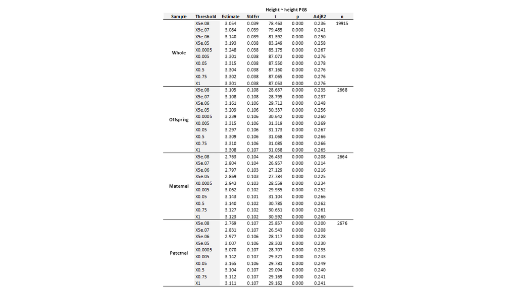

## Trio PGS Correlations

I am exploring PRSs generated using SNPs exceeding the p-value threshold of p<0.05  
Remember all variables are standardised - should interpret accordingly

```r
df <- read.table("IGE_height_PRS_df", header=T)

cor.test(df$heiPRS_0.05, df$mheiPRS_0.05)
cor.test(df$heiPRS_0.05, df$pheiPRS_0.05)
cor.test(df$mheiPRS_0.05, df$pheiPRS_0.05)

cor.test(df$HEIGHT, df$mHEIGHT)
cor.test(df$HEIGHT, df$pHEIGHT)
cor.test(df$mHEIGHT, df$pHEIGHT)

df <- merge(df, hei_res, by=c("FID", "IID"))

summary(lm(HEIGHT~heiPRS_0.05, data=df))
summary(lm(HEI_res~heiPRS_0.05, data=df))
summary(lm(mHEIGHT~mheiPRS_0.05, data=df))
summary(lm(pHEIGHT~pheiPRS_0.05, data=df))
```

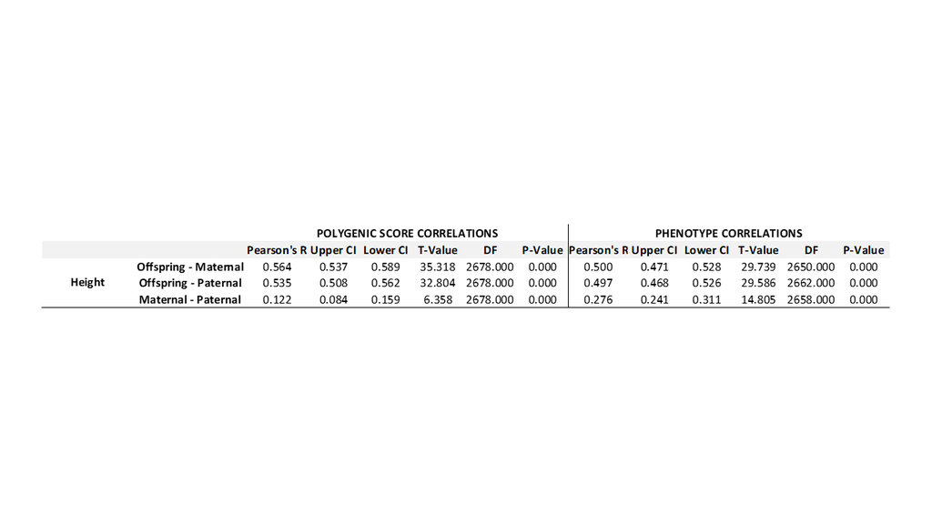

# DATAFRAMES

I will create separate dataframes for regression analyses and pathway analyses  
Resulting dataframes has all variables and covariates standardised

## Regression Dataframe

```r
library(dplyr)

#will not standardise parental height until properly residualised

GSheight <- read.table("GSheight", header=T)
outliers <- read.table("heightOUTLIERS", header=T)
GSheight <- GSheight[!(GSheight$IID%in%outliers$IID),]

hei <- GSheight
colnames(hei)[2:3] <- c("MID", "mHEI")

age <- read.table("GS_Ages.qcovar", header=T)
age <- age[,c(1:3)]
colnames(age) <- c("FID", "MID", "mAGE")

pcs <- read.table("HM3mds.mds", header=T)
pcs <- distinct(pcs, IID, .keep_all = TRUE) #Some IIDs are repeated, so need to sort this out#
pcs <- pcs[,-c(1,3)]
colnames(pcs)[1] <- "MID"

df <- merge(hei, age, by=c("FID", "MID"))
df2 <- merge(df, pcs, by="MID")
df2 <- df2[complete.cases(df2),]

#pre-correct maternal height for age and 20 PCs
res <- lm(mHEI~C1+C2+C3+C4+C5+C6+C7+C8+C9+C10+C11+C12+C13+C14+C15+C16+C17+C18+C19+C20+mAGE, data=df2)
result <- data.frame(FID=df2$FID, MID=df2$MID, mHEI_res=residuals(res))
result[,3] <- scale(result[,3]) #standardise this precorrected variable

colnames(hei)[2:3] <- c("PID", "pHEI")
colnames(age) <- c("FID", "PID", "pAGE")
colnames(pcs)[1] <- "PID"

df3 <- merge(hei, age, by=c("FID", "PID"))
df4 <- merge(df3, pcs, by="PID")
df4 <- df4[complete.cases(df4),]

res2 <- lm(pHEI~C1+C2+C3+C4+C5+C6+C7+C8+C9+C10+C11+C12+C13+C14+C15+C16+C17+C18+C19+C20+pAGE, data=df4)
result2 <- data.frame(FID=df4$FID, PID=df4$PID, pHEI_res=residuals(res2))
result2[,3] <- scale(result2[,3])

regdf <- read.table("IGE_height_PRS_df", header=T) #this df already has all variables standardised, so makes sense to add standardise the pre-corrected parental height variables

regdf <- regdf[!(regdf$IID%in%outliers$IID),] #making sure to remove outliers from this df
regdf <- merge(regdf, result, by=c("FID", "MID"), all.x=T)
regdf <- merge(regdf, result2, by=c("FID", "PID"), all.x=T)
names(regdf)

regdf$NFID <- paste(regdf$PID, regdf$MID, sep="_")
regdf <- regdf[complete.cases(regdf),]

write.table(regdf, "IGE_height_regression_df", row.names=F, quote=F)
#n=2,648
```

## Pathway Model Dataframe

Parent phenotypes are pre-corrected for PCs only - we can model AGE in the pathway models, in fact, results might be quite informative

```r
rm(list=ls())

library(dplyr)

hprs <- read.table("GSheight.all.score", header=T)
head(hprs)
hprs <- hprs[,c(1:2,9)]
colnames(hprs)[3] <- c("heiPRS_0.05")
dim(hprs)
hprs$heiPRS_0.05 <- scale(hprs$heiPRS_0.05)

trio <- read.table("GS_trio", header=T)
df <- trio[,c(1:4)]

height <- read.table("GSheight", header=T)
outliers <- read.table("heightOUTLIERS", header=T)
height <- height[!(height$IID%in%outliers$IID),]

sex <- read.table("GS_SexClinic.fcovar", header=T)
head(sex)
sex <- sex[,c(1:3)]
colnames(sex) <- c("FID", "IID", "SEX")
sex$SEX <- as.factor(sex$SEX)
dim(sex)

age <- read.table("GS_Ages.qcovar", header=T)
age <- age[,1:3]
age$AGE <- scale(age$age)
age <- age[,-3]
colnames(age) <- c("FID", "IID", "AGE")

pcs <- read.table("HM3mds.mds", header=T)
pcs <- distinct(pcs, IID, .keep_all = TRUE) #Some IIDs are repeated, so need to sort this out#
head(pcs)
pcs <- pcs[,-3]
dim(pcs)

##################################
##Precorrect parental phenotypes##
##################################

# maternal Height #

colnames(height)[2:3] <- c("MID", "mHEI")
colnames(pcs)[1:2] <- c("FID","MID")

dfm <- merge(height, pcs, by=c("FID","MID"))
dfm <- dfm[complete.cases(dfm),]

res <- lm(mHEI~C1+C2+C3+C4+C5+C6+C7+C8+C9+C10+C11+C12+C13+C14+C15+C16+C17+C18+C19+C20, data=dfm)
summary(res)
result <- data.frame(FID=dfm$FID, MID=dfm$MID, mHEI_res=residuals(res))
result[,3] <- scale(result[,3])

# paternal Height #

colnames(height)[2:3] <- c("PID", "pHEI")
colnames(pcs)[1:2] <- c("FID","PID")

dfp <- merge(height, pcs, by=c("FID","PID"))
dfp <- dfp[complete.cases(dfp),]

res <- lm(pHEI~C1+C2+C3+C4+C5+C6+C7+C8+C9+C10+C11+C12+C13+C14+C15+C16+C17+C18+C19+C20, data=dfp)
summary(res)
result2 <- data.frame(FID=dfp$FID, PID=dfp$PID, pHEI_res=residuals(res))
result2[,3] <- scale(result2[,3])

###
colnames(pcs)[1:2] <- c("FID", "IID")
pcs[3:22] <- scale(pcs[3:22])

colnames(height) <- c("FID", "IID", "HEIGHT")
height$HEIGHT <- scale(height$HEIGHT)

df1 <- merge(df, height, by=c("FID", "IID"), all.x=T)

colnames(height)[2:3] <- c("MID", "mHEI")
df2 <- merge(df1, height, by=c("FID", "MID"), all.x=T)

colnames(height)[2:3] <- c("PID", "pHEI")
df3 <- merge(df2, height, by=c("FID", "PID"), all.x=T)

df4 <- merge(df3, sex, by=c("FID", "IID"), all.x=T)

df5 <- merge(df4, age, by=c("FID", "IID"))

colnames(age)[2:3] <- c("MID", "mAGE")
df6 <- merge(df5, age, by=c("FID", "MID"))

colnames(age)[2:3] <- c("PID", "pAGE")
df7 <- merge(df6, age, by=c("FID", "PID"))

df8 <- merge(df7 , pcs, by=c("FID", "IID"))

df9 <- merge(df8, result, by=c("FID", "MID"), all.x=T)

df10 <- merge(df9, result2, by=c("FID", "PID"), all.x=T)

df11 <- merge(df10, hprs, by=c("FID", "IID"), all.x=T)

colnames(hprs)[2:3] <- c("MID", "mheiPRS_0.05")
df12 <- merge(df11, hprs, by=c("FID", "MID"), all.x=T)

colnames(hprs)[2:3] <- c("PID", "pheiPRS_0.05")
df13 <- merge(df12, hprs, by=c("FID", "PID"), all.x=T)

df13$NFID <- paste(df13$PID, df13$MID, sep="_")
names(df13)

write.table(df13, "IGE_height_pathway_df", row.names=F, quote=F)
```

## Pathway Model Dataframe (Maternal Duo)

```r
rm(list=ls())
library(dplyr)

hprs <- read.table("GSheight.all.score", header=T)
head(hprs)
hprs <- hprs[,c(1:2,9)]
colnames(hprs)[3] <- c("heiPRS_0.05")
dim(hprs)
hprs$heiPRS_0.05 <- scale(hprs$heiPRS_0.05)

duo <- read.table("GS_mat_duo", header=T)
df <- duo[,c(1:4)]

height <- read.table("GSheight", header=T)
outliers <- read.table("heightOUTLIERS", header=T)
height <- height[!(height$IID%in%outliers$IID),]

sex <- read.table("GS_SexClinic.fcovar", header=T)
head(sex)
sex <- sex[,c(1:3)]
colnames(sex) <- c("FID", "IID", "SEX")
sex$SEX <- as.factor(sex$SEX)
dim(sex)

age <- read.table("GS_Ages.qcovar", header=T)
age <- age[,1:3]
age$AGE <- scale(age$age)
age <- age[,-3]
colnames(age) <- c("FID", "IID", "AGE")

pcs <- read.table("HM3mds.mds", header=T)
pcs <- distinct(pcs, IID, .keep_all = TRUE) #Some IIDs are repeated, so need to sort this out#
head(pcs)
pcs <- pcs[,-3]
dim(pcs)

##################################
##Precorrect parental phenotypes##
##################################

# maternal Height #

colnames(height)[2:3] <- c("MID", "mHEI")
colnames(pcs)[1:2] <- c("FID","MID")

dfm <- merge(height, pcs, by=c("FID","MID"))
dfm <- dfm[complete.cases(dfm),]

res <- lm(mHEI~C1+C2+C3+C4+C5+C6+C7+C8+C9+C10+C11+C12+C13+C14+C15+C16+C17+C18+C19+C20, data=dfm)
summary(res)
result <- data.frame(FID=dfm$FID, MID=dfm$MID, mHEI_res=residuals(res))
result[,3] <- scale(result[,3])

###
colnames(pcs)[1:2] <- c("FID", "IID")
pcs[3:22] <- scale(pcs[3:22])

colnames(height) <- c("FID", "IID", "HEIGHT")
height$HEIGHT <- scale(height$HEIGHT)

df1 <- merge(df, height, by=c("FID", "IID"), all.x=T)

colnames(height)[2:3] <- c("MID", "mHEI")
df2 <- merge(df1, height, by=c("FID", "MID"), all.x=T)

df3 <- merge(df2, sex, by=c("FID", "IID"), all.x=T)

df4 <- merge(df3, age, by=c("FID", "IID"))

colnames(age)[2:3] <- c("MID", "mAGE")
df5 <- merge(df4, age, by=c("FID", "MID"))

df6 <- merge(df5 , pcs, by=c("FID", "IID"))

df7 <- merge(df6, result, by=c("FID", "MID"), all.x=T)

colnames(hprs)[2:3] <- c("IID", "heiPRS_0.05")
df8 <- merge(df7, hprs, by=c("FID", "IID"), all.x=T)

colnames(hprs)[2:3] <- c("MID", "mheiPRS_0.05")
df9 <- merge(df8, hprs, by=c("FID", "MID"), all.x=T)

df9$NFID <- paste(df9$PID, df9$MID, sep="_")
names(df9)

write.table(df9, "IGE_height_pathway_matduo_df", row.names=F, quote=F) #n = 5952
```

## Pathway Model Dataframe (Paternal Duo)

```r
rm(list=ls())
library(dplyr)

hprs <- read.table("GSheight.all.score", header=T)
head(hprs)
hprs <- hprs[,c(1:2,9)]
colnames(hprs)[3] <- c("heiPRS_0.05")
dim(hprs)
hprs$heiPRS_0.05 <- scale(hprs$heiPRS_0.05)

duo <- read.table("GS_pat_duo", header=T)
df <- duo[,c(1:4)]

height <- read.table("GSheight", header=T)
outliers <- read.table("heightOUTLIERS", header=T)
height <- height[!(height$IID%in%outliers$IID),]

sex <- read.table("GS_SexClinic.fcovar", header=T)
head(sex)
sex <- sex[,c(1:3)]
colnames(sex) <- c("FID", "IID", "SEX")
sex$SEX <- as.factor(sex$SEX)
dim(sex)

age <- read.table("GS_Ages.qcovar", header=T)
age <- age[,1:3]
age$AGE <- scale(age$age)
age <- age[,-3]
colnames(age) <- c("FID", "IID", "AGE")

pcs <- read.table("HM3mds.mds", header=T)
pcs <- distinct(pcs, IID, .keep_all = TRUE) #Some IIDs are repeated, so need to sort this out#
head(pcs)
pcs <- pcs[,-3]
dim(pcs)

##################################
##Precorrect parental phenotypes##
##################################

# paternal Height #

colnames(height)[2:3] <- c("PID", "pHEI")
colnames(pcs)[1:2] <- c("FID","PID")

dfp <- merge(height, pcs, by=c("FID","PID"))
dfp <- dfp[complete.cases(dfp),]

res <- lm(pHEI~C1+C2+C3+C4+C5+C6+C7+C8+C9+C10+C11+C12+C13+C14+C15+C16+C17+C18+C19+C20, data=dfp)
summary(res)
result <- data.frame(FID=dfp$FID, PID=dfp$PID, pHEI_res=residuals(res))
result[,3] <- scale(result[,3])

###
colnames(pcs)[1:2] <- c("FID", "IID")
pcs[3:22] <- scale(pcs[3:22])

colnames(height) <- c("FID", "IID", "HEIGHT")
height$HEIGHT <- scale(height$HEIGHT)

df1 <- merge(df, height, by=c("FID", "IID"), all.x=T)

colnames(height)[2:3] <- c("MID", "mHEI")
df2 <- merge(df1, height, by=c("FID", "MID"), all.x=T)

df3 <- merge(df2, sex, by=c("FID", "IID"), all.x=T)

df4 <- merge(df3, age, by=c("FID", "IID"))

colnames(age)[2:3] <- c("PID", "pAGE")
df5 <- merge(df4, age, by=c("FID", "PID"))

df6 <- merge(df5 , pcs, by=c("FID", "IID"))

df7 <- merge(df6, result, by=c("FID", "PID"), all.x=T)

colnames(hprs)[2:3] <- c("IID", "heiPRS_0.05")
df8 <- merge(df7, hprs, by=c("FID", "IID"), all.x=T)

colnames(hprs)[2:3] <- c("PID", "pheiPRS_0.05")
df9 <- merge(df8, hprs, by=c("FID", "PID"), all.x=T)

df9$NFID <- paste(df9$PID, df9$MID, sep="_")
names(df9)

write.table(df9, "IGE_height_pathway_patduo_df", row.names=F, quote=F) #n = 3865
```

# REGRESSION ANALYSES

**ALL VARIABLES ARE STANDARDISED - INTERPRET ACCORDINGLY**  
Meaning as the IV increases by 1 standard deviation, the DV increases by Estimate*SD  
All parent phenotypes are pre-corrected for their own 20 principle components and AGE

*I*. oHEI ~ oPRS *This model captures direct GE*  
*II*. oHEI ~ oPRS + mPRS + pPRS *This model captures both direct and indirect GE*

Models C and D can provide extra information

*III*. oHEI ~ oPRS + mHEI + pHEI  
*IV*. oHEI ~ oPRS + mHEI + pHEI + mPRS + pPRS

Comparison of the models using log likelihood can help us infer whether the effects of indirect genetic effects are present (specifically comparison of model *I* vs *II*)

There are siblings in my trio offsprings. It is important to control for these sibling effects which may bias the interpretation of results. Sibling effects will be fitted as random effects in these models. The package lmerTest will be used. Siblings have the same parent IDs, so we can use this as an indicator variable that can be fixed as random.

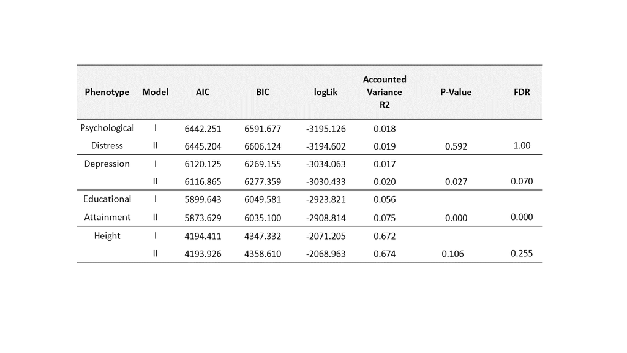

## Whole Sample

```r
rm(list=ls())

library(lmerTest) #this package allows us to run regression models with fixed and random effects
library(MuMIn) #this package allows us to obtain the R2 of our models, R2m (Marginal) R2 > fixed effects, R2c (Conditional) > whole model
library(dplyr)

regdf <- read.table("IGE_height_regression_df", header=T) #n=2648

#Model 0 is to understand the variance that is being accounted for by the covariates
Model0 <- lmer(HEIGHT~C1+C2+C3+C4+C5+C6+C7+C8+C9+C10+C11+C12+C13+C14+C15+C16+C17+C18+C19+C20+AGE+SEX+(1|NFID), data=regdf)

#only including results of AGE and SEX as this information is easy to understand and important
results_0 <- cbind(as.data.frame(coef(summary(Model0))[c(1,22,23),]),as.data.frame(r.squaredGLMM(Model0)))
results_0$Model <- "Model0"

ModelA <- lmer(HEIGHT~C1+C2+C3+C4+C5+C6+C7+C8+C9+C10+C11+C12+C13+C14+C15+C16+C17+C18+C19+C20+AGE+SEX+heiPRS_0.05+(1|NFID), data=regdf)
results_A <- cbind(as.data.frame(coef(summary(ModelA))[c(1,24),]),as.data.frame(r.squaredGLMM(ModelA)))
results_A$Model <- "ModelA"

ModelB <- lmer(HEIGHT~C1+C2+C3+C4+C5+C6+C7+C8+C9+C10+C11+C12+C13+C14+C15+C16+C17+C18+C19+C20+AGE+SEX+heiPRS_0.05+mheiPRS_0.05+pheiPRS_0.05+(1|NFID), data=regdf)
results_B <- cbind(as.data.frame(coef(summary(ModelB))[c(1,24:26),]),as.data.frame(r.squaredGLMM(ModelB)))
results_B$Model <- "ModelB"

ModelC <- lmer(HEIGHT~C1+C2+C3+C4+C5+C6+C7+C8+C9+C10+C11+C12+C13+C14+C15+C16+C17+C18+C19+C20+AGE+SEX+heiPRS_0.05+mHEI_res+pHEI_res+(1|NFID), data=regdf)
results_C <- cbind(as.data.frame(coef(summary(ModelC))[c(1,24:26),]),as.data.frame(r.squaredGLMM(ModelC)))
results_C$Model <- "ModelC"

ModelD <- lmer(HEIGHT~C1+C2+C3+C4+C5+C6+C7+C8+C9+C10+C11+C12+C13+C14+C15+C16+C17+C18+C19+C20+AGE+SEX+heiPRS_0.05+mheiPRS_0.05+pheiPRS_0.05+mHEI_res+pHEI_res+(1|NFID), data=regdf)
results_D <- cbind(as.data.frame(coef(summary(ModelD))[c(1,24:28),]),as.data.frame(r.squaredGLMM(ModelD)))
results_D$Model <- "ModelD"

results <- bind_rows(results_0, results_A, results_B, results_C, results_D)
write.csv(results, "heiPRS_0.05_reg_mixed_models.csv", row.names=T, quote=F)

avb <- as.data.frame(anova(ModelA, ModelB))
avb$comparison <- "A_v_B"

avc <- as.data.frame(anova(ModelA, ModelC))
avc$comparison <- "A_v_C"

avd <- as.data.frame(anova(ModelA, ModelD))
avd$comparison <- "A_v_D"

bvd <- as.data.frame(anova(ModelB, ModelD))
bvd$comparison <- "B_v_D"

cvd <- as.data.frame(anova(ModelC, ModelD))
cvd$comparison <- "C_v_D"

results <- bind_rows(avb, avc, avd, bvd, cvd)
results$fdr <- p.adjust(results$`Pr(>Chisq)`, method="fdr", n=length(results$`Pr(>Chisq)`))
write.csv(results, "heiPRS_0.05_reg_mixed_model_comparison.csv", row.names=T, quote=F)
```

## Female Only Sample

Results for the following can be found in the supplementary materials sheet 3

Even though sex is being controlled for in the above analyses, the analyses will be run separately in male and female offspring to explore any potential differences in the model results and comparisons.

```r
rm(list=ls())

library(lmerTest) #this package allows us to run regression models with fixed and random effects
library(MuMIn) #this package allows us to obtain the R2 of our models, R2m (Marginal) R2 > fixed effects, R2c (Conditional) > whole model
library(dplyr)

regdf <- read.table("IGE_height_regression_df", header=T)
regdf <- subset(regdf, regdf$SEX=="F") #n= 1498

#Model 0 is to understand the variance that is being accounted for by the covariates
Model0 <- lmer(HEIGHT~C1+C2+C3+C4+C5+C6+C7+C8+C9+C10+C11+C12+C13+C14+C15+C16+C17+C18+C19+C20+AGE+(1|NFID), data=regdf)

#only including results of AGE and SEX as this information is easy to understand and important
results_0 <- cbind(as.data.frame(coef(summary(Model0))[c(1,21,22),]),as.data.frame(r.squaredGLMM(Model0)))
results_0$Model <- "Model0"

ModelA <- lmer(HEIGHT~C1+C2+C3+C4+C5+C6+C7+C8+C9+C10+C11+C12+C13+C14+C15+C16+C17+C18+C19+C20+AGE+heiPRS_0.05+(1|NFID), data=regdf)
results_A <- cbind(as.data.frame(coef(summary(ModelA))[c(1,23),]),as.data.frame(r.squaredGLMM(ModelA)))
results_A$Model <- "ModelA"

ModelB <- lmer(HEIGHT~C1+C2+C3+C4+C5+C6+C7+C8+C9+C10+C11+C12+C13+C14+C15+C16+C17+C18+C19+C20+AGE+heiPRS_0.05+mheiPRS_0.05+pheiPRS_0.05+(1|NFID), data=regdf)
results_B <- cbind(as.data.frame(coef(summary(ModelB))[c(1,23:25),]),as.data.frame(r.squaredGLMM(ModelB)))
results_B$Model <- "ModelB"

ModelC <- lmer(HEIGHT~C1+C2+C3+C4+C5+C6+C7+C8+C9+C10+C11+C12+C13+C14+C15+C16+C17+C18+C19+C20+AGE+heiPRS_0.05+mHEI_res+pHEI_res+(1|NFID), data=regdf)
results_C <- cbind(as.data.frame(coef(summary(ModelC))[c(1,23:25),]),as.data.frame(r.squaredGLMM(ModelC)))
results_C$Model <- "ModelC"

ModelD <- lmer(HEIGHT~C1+C2+C3+C4+C5+C6+C7+C8+C9+C10+C11+C12+C13+C14+C15+C16+C17+C18+C19+C20+AGE+heiPRS_0.05+mheiPRS_0.05+pheiPRS_0.05+mHEI_res+pHEI_res+(1|NFID), data=regdf)
results_D <- cbind(as.data.frame(coef(summary(ModelD))[c(1,23:27),]),as.data.frame(r.squaredGLMM(ModelD)))
results_D$Model <- "ModelD"

results <- bind_rows(results_0, results_A, results_B, results_C, results_D)
write.csv(results, "heiPRS_0.05_reg_mixed_models_FEMALE.csv", row.names=T, quote=F)

avb <- as.data.frame(anova(ModelA, ModelB))
avb$comparison <- "A_v_B"

avc <- as.data.frame(anova(ModelA, ModelC))
avc$comparison <- "A_v_C"

avd <- as.data.frame(anova(ModelA, ModelD))
avd$comparison <- "A_v_D"

bvd <- as.data.frame(anova(ModelB, ModelD))
bvd$comparison <- "B_v_D"

cvd <- as.data.frame(anova(ModelC, ModelD))
cvd$comparison <- "C_v_D"

results <- bind_rows(avb, avc, avd, bvd, cvd)
results$fdr <- p.adjust(results$`Pr(>Chisq)`, method="fdr", n=length(results$`Pr(>Chisq)`))
write.csv(results, "heiPRS_0.05_reg_mixed_model_comparison_FEMALE.csv", row.names=T, quote=F)
```

## Male Only Sample

```r
rm(list=ls())

library(lmerTest) #this package allows us to run regression models with fixed and random effects
library(MuMIn) #this package allows us to obtain the R2 of our models, R2m (Marginal) R2 > fixed effects, R2c (Conditional) > whole model
library(dplyr)

regdf <- read.table("IGE_height_regression_df", header=T)
regdf <- subset(regdf, regdf$SEX=="M") #n= 1150

#Model 0 is to understand the variance that is being accounted for by the covariates
Model0 <- lmer(HEIGHT~C1+C2+C3+C4+C5+C6+C7+C8+C9+C10+C11+C12+C13+C14+C15+C16+C17+C18+C19+C20+AGE+(1|NFID), data=regdf)

#only including results of AGE and SEX as this information is easy to understand and important
results_0 <- cbind(as.data.frame(coef(summary(Model0))[c(1,21,22),]),as.data.frame(r.squaredGLMM(Model0)))
results_0$Model <- "Model0"

ModelA <- lmer(HEIGHT~C1+C2+C3+C4+C5+C6+C7+C8+C9+C10+C11+C12+C13+C14+C15+C16+C17+C18+C19+C20+AGE+heiPRS_0.05+(1|NFID), data=regdf)
results_A <- cbind(as.data.frame(coef(summary(ModelA))[c(1,23),]),as.data.frame(r.squaredGLMM(ModelA)))
results_A$Model <- "ModelA"

ModelB <- lmer(HEIGHT~C1+C2+C3+C4+C5+C6+C7+C8+C9+C10+C11+C12+C13+C14+C15+C16+C17+C18+C19+C20+AGE+heiPRS_0.05+mheiPRS_0.05+pheiPRS_0.05+(1|NFID), data=regdf)
results_B <- cbind(as.data.frame(coef(summary(ModelB))[c(1,23:25),]),as.data.frame(r.squaredGLMM(ModelB)))
results_B$Model <- "ModelB"

ModelC <- lmer(HEIGHT~C1+C2+C3+C4+C5+C6+C7+C8+C9+C10+C11+C12+C13+C14+C15+C16+C17+C18+C19+C20+AGE+heiPRS_0.05+mHEI_res+pHEI_res+(1|NFID), data=regdf)
results_C <- cbind(as.data.frame(coef(summary(ModelC))[c(1,23:25),]),as.data.frame(r.squaredGLMM(ModelC)))
results_C$Model <- "ModelC"

ModelD <- lmer(HEIGHT~C1+C2+C3+C4+C5+C6+C7+C8+C9+C10+C11+C12+C13+C14+C15+C16+C17+C18+C19+C20+AGE+heiPRS_0.05+mheiPRS_0.05+pheiPRS_0.05+mHEI_res+pHEI_res+(1|NFID), data=regdf)
results_D <- cbind(as.data.frame(coef(summary(ModelD))[c(1,23:27),]),as.data.frame(r.squaredGLMM(ModelD)))
results_D$Model <- "ModelD"

results <- bind_rows(results_0, results_A, results_B, results_C, results_D)
write.csv(results, "heiPRS_0.05_reg_mixed_models_MALE.csv", row.names=T, quote=F)

avb <- as.data.frame(anova(ModelA, ModelB))
avb$comparison <- "A_v_B"

avc <- as.data.frame(anova(ModelA, ModelC))
avc$comparison <- "A_v_C"

avd <- as.data.frame(anova(ModelA, ModelD))
avd$comparison <- "A_v_D"

bvd <- as.data.frame(anova(ModelB, ModelD))
bvd$comparison <- "B_v_D"

cvd <- as.data.frame(anova(ModelC, ModelD))
cvd$comparison <- "C_v_D"

results <- bind_rows(avb, avc, avd, bvd, cvd)
results[8,8] <- NA
results$fdr <- p.adjust(results$`Pr(>Chisq)`, method="fdr", n=length(results$`Pr(>Chisq)`))
write.csv(results, "heiPRS_0.05_reg_mixed_model_comparison_MALE.csv", row.names=T, quote=F)
```

## Singleton Sample

```r
rm(list=ls())

library(lmerTest) #this package allows us to run regression models with fixed and random effects
library(MuMIn) #this package allows us to obtain the R2 of our models, R2m (Marginal) R2 > fixed effects, R2c (Conditional) > whole model
library(dplyr)

regdf <- read.table("IGE_height_regression_df", header=T) #n=2648

#Model 0 is to understand the variance that is being accounted for by the covariates
Model0 <- lm(HEIGHT~C1+C2+C3+C4+C5+C6+C7+C8+C9+C10+C11+C12+C13+C14+C15+C16+C17+C18+C19+C20+AGE+SEX, data=regdf)

#only including results of AGE and SEX as this information is easy to understand and important
results_0 <- as.data.frame(cbind(coef(summary(Model0))[c(1,22:23),], summary(Model0)$adj.r.squared))
results_0$Model <- "Model0"

ModelA <- lm(HEIGHT~C1+C2+C3+C4+C5+C6+C7+C8+C9+C10+C11+C12+C13+C14+C15+C16+C17+C18+C19+C20+AGE+SEX+heiPRS_0.05, data=regdf)
results_A <- as.data.frame(cbind(coef(summary(ModelA))[c(1,24),], summary(ModelA)$adj.r.squared))
results_A$Model <- "ModelA"

ModelB <- lm(HEIGHT~C1+C2+C3+C4+C5+C6+C7+C8+C9+C10+C11+C12+C13+C14+C15+C16+C17+C18+C19+C20+AGE+SEX+heiPRS_0.05+mheiPRS_0.05+pheiPRS_0.05, data=regdf)
results_B <- as.data.frame(cbind(coef(summary(ModelB))[c(1,24:26),], summary(ModelB)$adj.r.squared))
results_B$Model <- "ModelB"

ModelC <- lm(HEIGHT~C1+C2+C3+C4+C5+C6+C7+C8+C9+C10+C11+C12+C13+C14+C15+C16+C17+C18+C19+C20+AGE+SEX+heiPRS_0.05+mHEI_res+pHEI_res, data=regdf)
results_C <- as.data.frame(cbind(coef(summary(ModelC))[c(1,24:26),], summary(ModelC)$adj.r.squared))
results_C$Model <- "ModelC"

ModelD <- lm(HEIGHT~C1+C2+C3+C4+C5+C6+C7+C8+C9+C10+C11+C12+C13+C14+C15+C16+C17+C18+C19+C20+AGE+SEX+heiPRS_0.05+mheiPRS_0.05+pheiPRS_0.05+mHEI_res+pHEI_res, data=regdf)
results_D <- as.data.frame(cbind(coef(summary(ModelD))[c(1,24:28),], summary(ModelD)$adj.r.squared))
results_D$Model <- "ModelD"

results <- bind_rows(results_0, results_A, results_B, results_C, results_D)
write.csv(results, "heiPRS_0.05_reg_mixed_models_nosib.csv", row.names=T, quote=F)

avb <- as.data.frame(anova(ModelA, ModelB))
avb$comparison <- "A_v_B"

avc <- as.data.frame(anova(ModelA, ModelC))
avc$comparison <- "A_v_C"

avd <- as.data.frame(anova(ModelA, ModelD))
avd$comparison <- "A_v_D"

bvd <- as.data.frame(anova(ModelB, ModelD))
bvd$comparison <- "B_v_D"

cvd <- as.data.frame(anova(ModelC, ModelD))
cvd$comparison <- "C_v_D"

results <- bind_rows(avb, avc, avd, bvd, cvd)
results$fdr <- p.adjust(results$`Pr(>F)`, method="fdr", n=length(results$`Pr(>F)`))
write.csv(results, "heiPRS_0.05_reg_mixed_model_comparison_nosib.csv", row.names=T, quote=F)
```

# PATHWAY ANALYSES

Pathway analyses can model the relationships between the IVs unlike regression models. Coefficients, however, can be interpreted in the same way you would with regression models.

Simple model  
Extended model

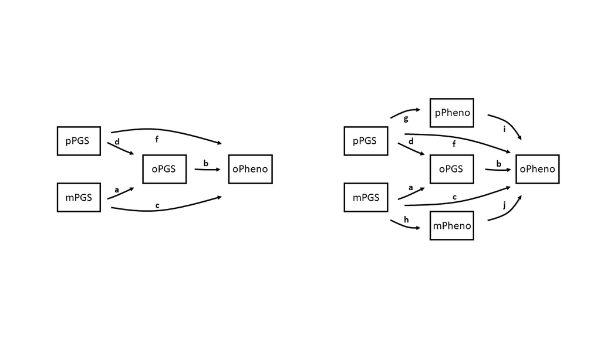

Results can be found in supplementary Table 4.

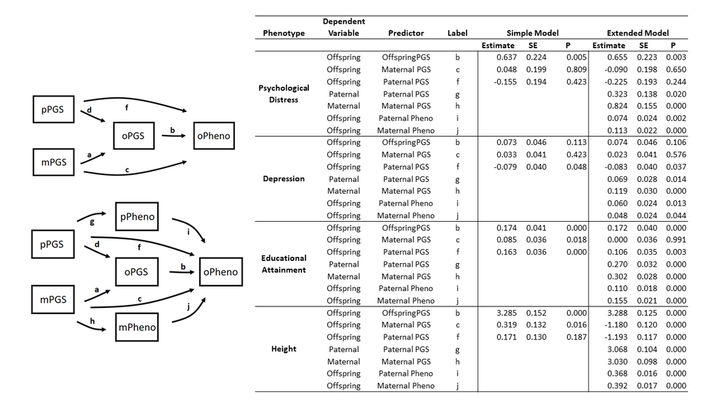

## Paths h,i Restricted

Note that parent phenotypes are pre-corrected for their own 20 principle components from a GRM of Generation Scotland. The phenotype was not pre-corrected for AGE, instead, this was included in the statistical model as this could provide useful information without making the results difficult to read.

```r
rm(list=ls())
library(lavaan)

data <- read.table("IGE_height_pathway_df", header=T)
data <- data[complete.cases(data),] #n=2648

##############
#SIMPLE MODEL#
##############

# Define model

model <- '

# direct effects
HEIGHT ~ AGE+SEX+C1+C2+C3+C4+C5+C6+C7+C8+C9+C10+C11+C12+C13+C14+C15+C16+C17+C18+C19+C20
HEIGHT ~ c*mheiPRS_0.05
HEIGHT ~ b*pheiPRS_0.05

# mediator
heiPRS_0.05 ~ 0.5*mheiPRS_0.05
heiPRS_0.05 ~ 0.5*pheiPRS_0.05
HEIGHT ~ a*heiPRS_0.05

# indirect effects (i*a, h*a)
ia := 0.5*a
ha := 0.5*a

# total effects
total_mum := c + (0.5*a)
total_dad := b + (0.5*a)

# covariance
mheiPRS_0.05 ~~ pheiPRS_0.05
'

# Fit the model
fitM <- sem(model, data=data, estimator='ML')

sem_model <- summary(fitM, standardized=TRUE, fit.measures=TRUE, ci=TRUE)
sem_model_df <- as.data.frame(sem_model$PE)
sem_model_final <- sem_model_df[sem_model_df$label != "", c(1:4,6:7,9:11)] #here we are extracting values of interest e.g. est, se, p, ci
simple_model <- cbind(sem_model_final, AIC(fitM))

write.csv(simple_model, "heiPRS_0.05_pa_m1.csv", row.names=F, quote=F)

################
#EXTENDED MODEL#
################

rm(list=ls())
data <- read.table("IGE_height_pathway_df", header=T)
data <- data[complete.cases(data),]

# Define model

model <- '

#direct effects
HEIGHT ~ AGE+SEX+C1+C2+C3+C4+C5+C6+C7+C8+C9+C10+C11+C12+C13+C14+C15+C16+C17+C18+C19+C20
HEIGHT ~ c*mheiPRS_0.05
HEIGHT ~ b*pheiPRS_0.05

#mediator
heiPRS_0.05 ~ 0.5*mheiPRS_0.05
heiPRS_0.05 ~ 0.5*pheiPRS_0.05

HEIGHT ~ a*heiPRS_0.05

pHEI_res ~ d*pheiPRS_0.05+pAGE
mHEI_res ~ e*mheiPRS_0.05+mAGE

HEIGHT ~ f*pHEI_res
HEIGHT ~ g*mHEI_res

# indirect effects (i*a, h*a)
ia := 0.5*a
ha := 0.5*a
df := d*f
eg := e*g


# total effects
total_mum := c + (0.5*a) + (e*g)
total_dad := b + (0.5*a) + (d*f)

# covariance
mheiPRS_0.05 ~~ pheiPRS_0.05
mHEI_res ~~ pHEI_res

'

# Fit the model
fitM <- sem(model, data=data, estimator='ML')
sem_model <- summary(fitM, standardized=TRUE, fit.measures=TRUE, ci=TRUE)
sem_model_df <- as.data.frame(sem_model$PE)
sem_model_final <- sem_model_df[sem_model_df$label != "", c(1:4,6:7,9:11)] #here we are extracting values of interest e.g. est, se, p, ci
extended_model <- cbind(sem_model_final, AIC(fitM))

write.csv(extended_model, "heiPRS_0.05_pa_m2.csv", row.names=F, quote=F)
```

## Paths Freely Estimated

```r
rm(list=ls())
library(lavaan)

data <- read.table("IGE_height_pathway_df", header=T)
data <- data[complete.cases(data),] #n=2648

##############
#SIMPLE MODEL#
##############

# Define model

model <- '

# direct effects
HEIGHT ~ AGE+SEX+C1+C2+C3+C4+C5+C6+C7+C8+C9+C10+C11+C12+C13+C14+C15+C16+C17+C18+C19+C20
HEIGHT ~ c*mheiPRS_0.05
HEIGHT ~ b*pheiPRS_0.05

# mediator
heiPRS_0.05 ~ i*mheiPRS_0.05
heiPRS_0.05 ~ h*pheiPRS_0.05
HEIGHT ~ a*heiPRS_0.05

# indirect effects (i*a, h*a)
ia := i*a
ha := h*a

# total effects
total_mum := c + (i*a)
total_dad := b + (h*a)

# covariance
mheiPRS_0.05 ~~ pheiPRS_0.05
'

# Fit the model
fitM <- sem(model, data=data, estimator='ML')

sem_model <- summary(fitM, standardized=TRUE, fit.measures=TRUE, ci=TRUE)
sem_model_df <- as.data.frame(sem_model$PE)
sem_model_final <- sem_model_df[sem_model_df$label != "", c(1:4,6:7,9:11)] #here we are extracting values of interest e.g. est, se, p, ci
simple_model <- cbind(sem_model_final, AIC(fitM))

write.csv(simple_model, "heiPRS_0.05_pa_m1_fm.csv", row.names=F, quote=F) #fm stands for free model

################
#EXTENDED MODEL#
################

rm(list=ls())
data <- read.table("IGE_height_pathway_df", header=T)
data <- data[complete.cases(data),]

# Define model

model <- '

#direct effects
HEIGHT ~ AGE+SEX+C1+C2+C3+C4+C5+C6+C7+C8+C9+C10+C11+C12+C13+C14+C15+C16+C17+C18+C19+C20
HEIGHT ~ c*mheiPRS_0.05
HEIGHT ~ b*pheiPRS_0.05

#mediator
heiPRS_0.05 ~ i*mheiPRS_0.05
heiPRS_0.05 ~ h*pheiPRS_0.05

HEIGHT ~ a*heiPRS_0.05

pHEI_res ~ d*pheiPRS_0.05+pAGE
mHEI_res ~ e*mheiPRS_0.05+mAGE

HEIGHT ~ f*pHEI_res
HEIGHT ~ g*mHEI_res

# indirect effects (i*a, h*a)
ia := i*a
ha := h*a
df := d*f
eg := e*g


# total effects
total_mum := c + (i*a) + (e*g)
total_dad := b + (h*a) + (d*f)

# covariance
mheiPRS_0.05 ~~ pheiPRS_0.05
mHEI_res ~~ pHEI_res

'

# Fit the model
fitM <- sem(model, data=data, estimator='ML')
sem_model <- summary(fitM, standardized=TRUE, fit.measures=TRUE, ci=TRUE)
sem_model_df <- as.data.frame(sem_model$PE)
sem_model_final <- sem_model_df[sem_model_df$label != "", c(1:4,6:7,9:11)] #here we are extracting values of interest e.g. est, se, p, ci
extended_model <- cbind(sem_model_final, AIC(fitM))

write.csv(extended_model, "heiPRS_0.05_pa_m2_fm.csv", row.names=F, quote=F)
```

## Parent PGS Covariance

Here we will run the analyses WITHOUT controlling for parent PGS covariance to see if results change vastly, we want to see if this is effectively controlling for assortative mating effects.

```r
rm(list=ls())
library(lavaan)

data <- read.table("IGE_height_pathway_df", header=T)
data <- data[complete.cases(data),] #n=2648

##############
#SIMPLE MODEL#
##############

# Define model

model <- '

# direct effects
HEIGHT ~ AGE+SEX+C1+C2+C3+C4+C5+C6+C7+C8+C9+C10+C11+C12+C13+C14+C15+C16+C17+C18+C19+C20
HEIGHT ~ c*mheiPRS_0.05
HEIGHT ~ b*pheiPRS_0.05

# mediator
heiPRS_0.05 ~ i*mheiPRS_0.05
heiPRS_0.05 ~ h*pheiPRS_0.05
HEIGHT ~ a*heiPRS_0.05

# indirect effects (i*a, h*a)
ia := i*a
ha := h*a

# total effects
total_mum := c + (i*a)
total_dad := b + (h*a)

# covariance

'

# Fit the model
fitM <- sem(model, data=data, estimator='ML')

sem_model <- summary(fitM, standardized=TRUE, fit.measures=TRUE, ci=TRUE)
sem_model_df <- as.data.frame(sem_model$PE)
sem_model_final <- sem_model_df[sem_model_df$label != "", c(1:4,6:7,9:11)] #here we are extracting values of interest e.g. est, se, p, ci
simple_model <- cbind(sem_model_final, AIC(fitM))

write.csv(simple_model, "heiPRS_0.05_pa_m1_parentPGScov_notcontrolled.csv", row.names=F, quote=F) #fm stands for free model

################
#EXTENDED MODEL#
################

rm(list=ls())
data <- read.table("IGE_height_pathway_df", header=T)
data <- data[complete.cases(data),]

# Define model

model <- '

#direct effects
HEIGHT ~ AGE+SEX+C1+C2+C3+C4+C5+C6+C7+C8+C9+C10+C11+C12+C13+C14+C15+C16+C17+C18+C19+C20
HEIGHT ~ c*mheiPRS_0.05
HEIGHT ~ b*pheiPRS_0.05

#mediator
heiPRS_0.05 ~ i*mheiPRS_0.05
heiPRS_0.05 ~ h*pheiPRS_0.05

HEIGHT ~ a*heiPRS_0.05

pHEI_res ~ d*pheiPRS_0.05+pAGE
mHEI_res ~ e*mheiPRS_0.05+mAGE

HEIGHT ~ f*pHEI_res
HEIGHT ~ g*mHEI_res

# indirect effects (i*a, h*a)
ia := i*a
ha := h*a
df := d*f
eg := e*g


# total effects
total_mum := c + (i*a) + (e*g)
total_dad := b + (h*a) + (d*f)

# covariance

'

# Fit the model
fitM <- sem(model, data=data, estimator='ML')
sem_model <- summary(fitM, standardized=TRUE, fit.measures=TRUE, ci=TRUE)
sem_model_df <- as.data.frame(sem_model$PE)
sem_model_final <- sem_model_df[sem_model_df$label != "", c(1:4,6:7,9:11)] #here we are extracting values of interest e.g. est, se, p, ci
extended_model <- cbind(sem_model_final, AIC(fitM))

write.csv(extended_model, "heiPRS_0.05_pa_m2_parentPGScov_notcontrolled.csv", row.names=F, quote=F)
```

## Female Only Sample

```r
rm(list=ls())
library(lavaan)

data <- read.table("IGE_height_pathway_df", header=T)
data <- subset(data, data$SEX=="F")
data <- data[complete.cases(data),] #n=1498

##############
#SIMPLE MODEL#
##############

# Define model

model <- '

# direct effects
HEIGHT ~ AGE+C1+C2+C3+C4+C5+C6+C7+C8+C9+C10+C11+C12+C13+C14+C15+C16+C17+C18+C19+C20
HEIGHT ~ c*mheiPRS_0.05
HEIGHT ~ b*pheiPRS_0.05

# mediator
heiPRS_0.05 ~ 0.5*mheiPRS_0.05
heiPRS_0.05 ~ 0.5*pheiPRS_0.05
HEIGHT ~ a*heiPRS_0.05

# indirect effects (i*a, h*a)
ia := 0.5*a
ha := 0.5*a

# total effects
total_mum := c + (0.5*a)
total_dad := b + (0.5*a)

# covariance
mheiPRS_0.05 ~~ pheiPRS_0.05
'

# Fit the model
fitM <- sem(model, data=data, estimator='ML')

sem_model <- summary(fitM, standardized=TRUE, fit.measures=TRUE, ci=TRUE)
sem_model_df <- as.data.frame(sem_model$PE)
sem_model_final <- sem_model_df[sem_model_df$label != "", c(1:4,6:7,9:11)] #here we are extracting values of interest e.g. est, se, p, ci
simple_model <- cbind(sem_model_final, AIC(fitM))

write.csv(simple_model, "heiPRS_0.05_pa_m1_FEMALE.csv", row.names=F, quote=F)

################
#EXTENDED MODEL#
################

rm(list=ls())
data <- read.table("IGE_height_pathway_df", header=T)
data <- subset(data, data$SEX=="F")
data <- data[complete.cases(data),] #n=1498

model <- '

#direct effects
HEIGHT ~ AGE+C1+C2+C3+C4+C5+C6+C7+C8+C9+C10+C11+C12+C13+C14+C15+C16+C17+C18+C19+C20
HEIGHT ~ c*mheiPRS_0.05
HEIGHT ~ b*pheiPRS_0.05

#mediator
heiPRS_0.05 ~ 0.5*mheiPRS_0.05
heiPRS_0.05 ~ 0.5*pheiPRS_0.05

HEIGHT ~ a*heiPRS_0.05

pHEI_res ~ d*pheiPRS_0.05+pAGE
mHEI_res ~ e*mheiPRS_0.05+mAGE

HEIGHT ~ f*pHEI_res
HEIGHT ~ g*mHEI_res

# indirect effects (i*a, h*a)
ia := 0.5*a
ha := 0.5*a
df := d*f
eg := e*g


# total effects
total_mum := c + (0.5*a) + (e*g)
total_dad := b + (0.5*a) + (d*f)

# covariance
mheiPRS_0.05 ~~ pheiPRS_0.05
mHEI_res ~~ pHEI_res

'

# Fit the model
fitM <- sem(model, data=data, estimator='ML')
sem_model <- summary(fitM, standardized=TRUE, fit.measures=TRUE, ci=TRUE)
sem_model_df <- as.data.frame(sem_model$PE)
sem_model_final <- sem_model_df[sem_model_df$label != "", c(1:4,6:7,9:11)] #here we are extracting values of interest e.g. est, se, p, ci
extended_model <- cbind(sem_model_final, AIC(fitM))

write.csv(extended_model, "heiPRS_0.05_pa_m2_FEMALE.csv", row.names=F, quote=F)
```

## Male Only Sample

```r
rm(list=ls())
library(lavaan)

data <- read.table("IGE_height_pathway_df", header=T)
data <- subset(data, data$SEX=="M")
data <- data[complete.cases(data),] ##n=1150

##############
#SIMPLE MODEL#
##############

# Define model

model <- '

# direct effects
HEIGHT ~ AGE+C1+C2+C3+C4+C5+C6+C7+C8+C9+C10+C11+C12+C13+C14+C15+C16+C17+C18+C19+C20
HEIGHT ~ c*mheiPRS_0.05
HEIGHT ~ b*pheiPRS_0.05

# mediator
heiPRS_0.05 ~ 0.5*mheiPRS_0.05
heiPRS_0.05 ~ 0.5*pheiPRS_0.05
HEIGHT ~ a*heiPRS_0.05

# indirect effects (i*a, h*a)
ia := 0.5*a
ha := 0.5*a

# total effects
total_mum := c + (0.5*a)
total_dad := b + (0.5*a)

# covariance
mheiPRS_0.05 ~~ pheiPRS_0.05
'

# Fit the model
fitM <- sem(model, data=data, estimator='ML')

sem_model <- summary(fitM, standardized=TRUE, fit.measures=TRUE, ci=TRUE)
sem_model_df <- as.data.frame(sem_model$PE)
sem_model_final <- sem_model_df[sem_model_df$label != "", c(1:4,6:7,9:11)] #here we are extracting values of interest e.g. est, se, p, ci
simple_model <- cbind(sem_model_final, AIC(fitM))

write.csv(simple_model, "heiPRS_0.05_pa_m1_MALE.csv", row.names=F, quote=F)

################
#EXTENDED MODEL#
################

rm(list=ls())
data <- read.table("IGE_height_pathway_df", header=T)
data <- subset(data, data$SEX=="M")
data <- data[complete.cases(data),] ##n=1150

model <- '

#direct effects
HEIGHT ~ AGE+C1+C2+C3+C4+C5+C6+C7+C8+C9+C10+C11+C12+C13+C14+C15+C16+C17+C18+C19+C20
HEIGHT ~ c*mheiPRS_0.05
HEIGHT ~ b*pheiPRS_0.05

#mediator
heiPRS_0.05 ~ 0.5*mheiPRS_0.05
heiPRS_0.05 ~ 0.5*pheiPRS_0.05

HEIGHT ~ a*heiPRS_0.05

pHEI_res ~ d*pheiPRS_0.05+pAGE
mHEI_res ~ e*mheiPRS_0.05+mAGE

HEIGHT ~ f*pHEI_res
HEIGHT ~ g*mHEI_res

# indirect effects (i*a, h*a)
ia := 0.5*a
ha := 0.5*a
df := d*f
eg := e*g


# total effects
total_mum := c + (0.5*a) + (e*g)
total_dad := b + (0.5*a) + (d*f)

# covariance
mheiPRS_0.05 ~~ pheiPRS_0.05
mHEI_res ~~ pHEI_res

'

# Fit the model
fitM <- sem(model, data=data, estimator='ML')
sem_model <- summary(fitM, standardized=TRUE, fit.measures=TRUE, ci=TRUE)
sem_model_df <- as.data.frame(sem_model$PE)
sem_model_final <- sem_model_df[sem_model_df$label != "", c(1:4,6:7,9:11)] #here we are extracting values of interest e.g. est, se, p, ci
extended_model <- cbind(sem_model_final, AIC(fitM))

write.csv(extended_model, "heiPRS_0.05_pa_m2_MALE.csv", row.names=F, quote=F)
```

## Singleton Sample

Removing siblings to double check that estimates do not change substantially

```r
rm(list=ls())
library(lavaan)
library(dplyr)
data <- read.table("IGE_height_pathway_df", header=T)
data <- data[!duplicated(data$NFID),] #removing 1 individual from a sibling group
data <- data[complete.cases(data),] #n=1579

##############
#SIMPLE MODEL#
##############

# Define model

model <- '

# direct effects
HEIGHT ~ AGE+SEX+C1+C2+C3+C4+C5+C6+C7+C8+C9+C10+C11+C12+C13+C14+C15+C16+C17+C18+C19+C20
HEIGHT ~ c*mheiPRS_0.05
HEIGHT ~ b*pheiPRS_0.05

# mediator
heiPRS_0.05 ~ 0.5*mheiPRS_0.05
heiPRS_0.05 ~ 0.5*pheiPRS_0.05
HEIGHT ~ a*heiPRS_0.05

# indirect effects (i*a, h*a)
ia := 0.5*a
ha := 0.5*a

# total effects
total_mum := c + (0.5*a)
total_dad := b + (0.5*a)

# covariance
mheiPRS_0.05 ~~ pheiPRS_0.05
'

# Fit the model
fitM <- sem(model, data=data, estimator='ML')

sem_model <- summary(fitM, standardized=TRUE, fit.measures=TRUE, ci=TRUE)
sem_model_df <- as.data.frame(sem_model$PE)
sem_model_final <- sem_model_df[sem_model_df$label != "", c(1:4,6:7,9:11)] #here we are extracting values of interest e.g. est, se, p, ci
simple_model <- cbind(sem_model_final, AIC(fitM))

write.csv(simple_model, "heiPRS_0.05_pa_m1_nosib.csv", row.names=F, quote=F)

################
#EXTENDED MODEL#
################

rm(list=ls())
data <- read.table("IGE_height_pathway_df", header=T)
data <- data[!duplicated(data$NFID),]
data <- data[complete.cases(data),] #n=1579

model <- '

#direct effects
HEIGHT ~ AGE+SEX+C1+C2+C3+C4+C5+C6+C7+C8+C9+C10+C11+C12+C13+C14+C15+C16+C17+C18+C19+C20
HEIGHT ~ c*mheiPRS_0.05
HEIGHT ~ b*pheiPRS_0.05

#mediator
heiPRS_0.05 ~ 0.5*mheiPRS_0.05
heiPRS_0.05 ~ 0.5*pheiPRS_0.05

HEIGHT ~ a*heiPRS_0.05

pHEI_res ~ d*pheiPRS_0.05+pAGE
mHEI_res ~ e*mheiPRS_0.05+mAGE

HEIGHT ~ f*pHEI_res
HEIGHT ~ g*mHEI_res

# indirect effects (i*a, h*a)
ia := 0.5*a
ha := 0.5*a
df := d*f
eg := e*g


# total effects
total_mum := c + (0.5*a) + (e*g)
total_dad := b + (0.5*a) + (d*f)

# covariance
mheiPRS_0.05 ~~ pheiPRS_0.05
mHEI_res ~~ pHEI_res

'

# Fit the model
fitM <- sem(model, data=data, estimator='ML')
sem_model <- summary(fitM, standardized=TRUE, fit.measures=TRUE, ci=TRUE)
sem_model_df <- as.data.frame(sem_model$PE)
sem_model_final <- sem_model_df[sem_model_df$label != "", c(1:4,6:7,9:11)] #here we are extracting values of interest e.g. est, se, p, ci
extended_model <- cbind(sem_model_final, AIC(fitM))

write.csv(extended_model, "heiPRS_0.05_pa_m2_nosib.csv", row.names=F, quote=F)
```

## Maternal Duo Sample

```r
rm(list=ls())
library(lavaan)

data <- read.table("IGE_height_pathway_matduo_df", header=T)
data <- data[complete.cases(data),] #n=5896

##############
#SIMPLE MODEL#
##############

# Define model

model <- '

# direct effects
HEIGHT ~ AGE+SEX+C1+C2+C3+C4+C5+C6+C7+C8+C9+C10+C11+C12+C13+C14+C15+C16+C17+C18+C19+C20
HEIGHT ~ c*mheiPRS_0.05

# mediator
heiPRS_0.05 ~ 0.5*mheiPRS_0.05
HEIGHT ~ a*heiPRS_0.05

# indirect effects (i*a)
ia := 0.5*a

# total effects
total_mum := c + (0.5*a)
'

# Fit the model
fitM <- sem(model, data=data, estimator='ML')

sem_model <- summary(fitM, standardized=TRUE, fit.measures=TRUE, ci=TRUE)
sem_model_df <- as.data.frame(sem_model$PE)
sem_model_final <- sem_model_df[sem_model_df$label != "", c(1:4,6:7,9:11)] #here we are extracting values of interest e.g. est, se, p, ci
simple_model <- cbind(sem_model_final, AIC(fitM))

write.csv(simple_model, "heiPRS_0.05_pa_m1_matduo.csv", row.names=F, quote=F)

################
#EXTENDED MODEL#
################

rm(list=ls())
data <- read.table("IGE_height_pathway_matduo_df", header=T)
data <- data[complete.cases(data),] #n=5896

# Define model

model <- '

#direct effects
HEIGHT ~ AGE+SEX+C1+C2+C3+C4+C5+C6+C7+C8+C9+C10+C11+C12+C13+C14+C15+C16+C17+C18+C19+C20
HEIGHT ~ c*mheiPRS_0.05

#mediator
heiPRS_0.05 ~ 0.5*mheiPRS_0.05

HEIGHT ~ a*heiPRS_0.05

mHEI_res ~ e*mheiPRS_0.05+mAGE

HEIGHT ~ g*mHEI_res

# indirect effects (i*a, e*g)
ia := 0.5*a
eg := e*g


# total effects
total_mum := c + (0.5*a) + (e*g)

'

# Fit the model
fitM <- sem(model, data=data, estimator='ML')
sem_model <- summary(fitM, standardized=TRUE, fit.measures=TRUE, ci=TRUE)
sem_model_df <- as.data.frame(sem_model$PE)
sem_model_final <- sem_model_df[sem_model_df$label != "", c(1:4,6:7,9:11)] #here we are extracting values of interest e.g. est, se, p, ci
extended_model <- cbind(sem_model_final, AIC(fitM))

write.csv(extended_model, "heiPRS_0.05_pa_m2_matduo.csv", row.names=F, quote=F)
```

## Paternal Duo Sample

```r
rm(list=ls())
library(lavaan)

data <- read.table("IGE_height_pathway_patduo_df", header=T)
data <- data[complete.cases(data),] #n=2732

##############
#SIMPLE MODEL#
##############

# Define model

model <- '

# direct effects
HEIGHT ~ AGE+SEX+C1+C2+C3+C4+C5+C6+C7+C8+C9+C10+C11+C12+C13+C14+C15+C16+C17+C18+C19+C20

HEIGHT ~ b*pheiPRS_0.05

# mediator
heiPRS_0.05 ~ 0.5*pheiPRS_0.05
HEIGHT ~ a*heiPRS_0.05

# indirect effects (h*a)
ha := 0.5*a

# total effects
total_dad := b + (0.5*a)

'

# Fit the model
fitM <- sem(model, data=data, estimator='ML')

sem_model <- summary(fitM, standardized=TRUE, fit.measures=TRUE, ci=TRUE)
sem_model_df <- as.data.frame(sem_model$PE)
sem_model_final <- sem_model_df[sem_model_df$label != "", c(1:4,6:7,9:11)] #here we are extracting values of interest e.g. est, se, p, ci
simple_model <- cbind(sem_model_final, AIC(fitM))

write.csv(simple_model, "heiPRS_0.05_pa_m1_patduo.csv", row.names=F, quote=F)

################
#EXTENDED MODEL#
################

rm(list=ls())
data <- read.table("IGE_height_pathway_patduo_df", header=T)
data <- data[complete.cases(data),] #n=2732

# Define model

model <- '

#direct effects
HEIGHT ~ AGE+SEX+C1+C2+C3+C4+C5+C6+C7+C8+C9+C10+C11+C12+C13+C14+C15+C16+C17+C18+C19+C20
HEIGHT ~ b*pheiPRS_0.05

#mediator
heiPRS_0.05 ~ 0.5*pheiPRS_0.05

HEIGHT ~ a*heiPRS_0.05

pHEI_res ~ d*pheiPRS_0.05+pAGE

HEIGHT ~ f*pHEI_res

# indirect effects (h*a, d*f)
ha := 0.5*a
df := d*f



# total effects
total_dad := b + (0.5*a) + (d*f)

'

# Fit the model
fitM <- sem(model, data=data, estimator='ML')
sem_model <- summary(fitM, standardized=TRUE, fit.measures=TRUE, ci=TRUE)
sem_model_df <- as.data.frame(sem_model$PE)
sem_model_final <- sem_model_df[sem_model_df$label != "", c(1:4,6:7,9:11)] #here we are extracting values of interest e.g. est, se, p, ci
extended_model <- cbind(sem_model_final, AIC(fitM))

write.csv(extended_model, "heiPRS_0.05_pa_m2_patduo.csv", row.names=F, quote=F)
```